```python
# import <needed_package_name>
import sys
import math # For Math functions
import sympy as sym # For declaring variables as symbols, make sure you have sympy installed in your system
from sympy import symbols
from sympy import *
```

# Problem 1

We have been given a KUKA WIIA robot. We need to calculate the Inverse Kinematics of the robot arm.

Since the problem is same as the one we solved for hoemwork 3 and since we've been given instructions to take values from the previous problem, hence we are going to take the information from the previous solution (HW3)

# Solution

We have been given a seven DOF Kuka robot. We need to solve for the forward kinematics of the robot by applying the method given by Denavit-Hartenberg.

By following the rules layed out by the D-H convention of solving the problem

1. Make the zi - axes for all frames (along the axis of actuation of joint i+1)
2. The base frame is already mentioned in the problem
3. Now we need to assign the xi - axes for all frames by checking the relation between zi-1 and zi (if they are coplanar (parallel or intersect) or not coplanar)
4. After all xi - axes are assigned, we complete the frame by attaching the yi - axes to complete the Right Handed Frame rule

The co-ordinate frames are shown as below figure

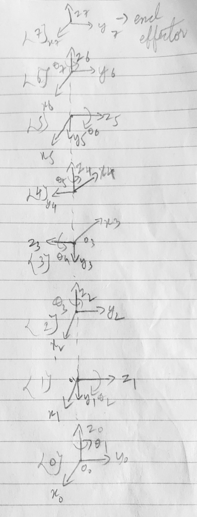

### The D-H Parameters table is mentioned as below

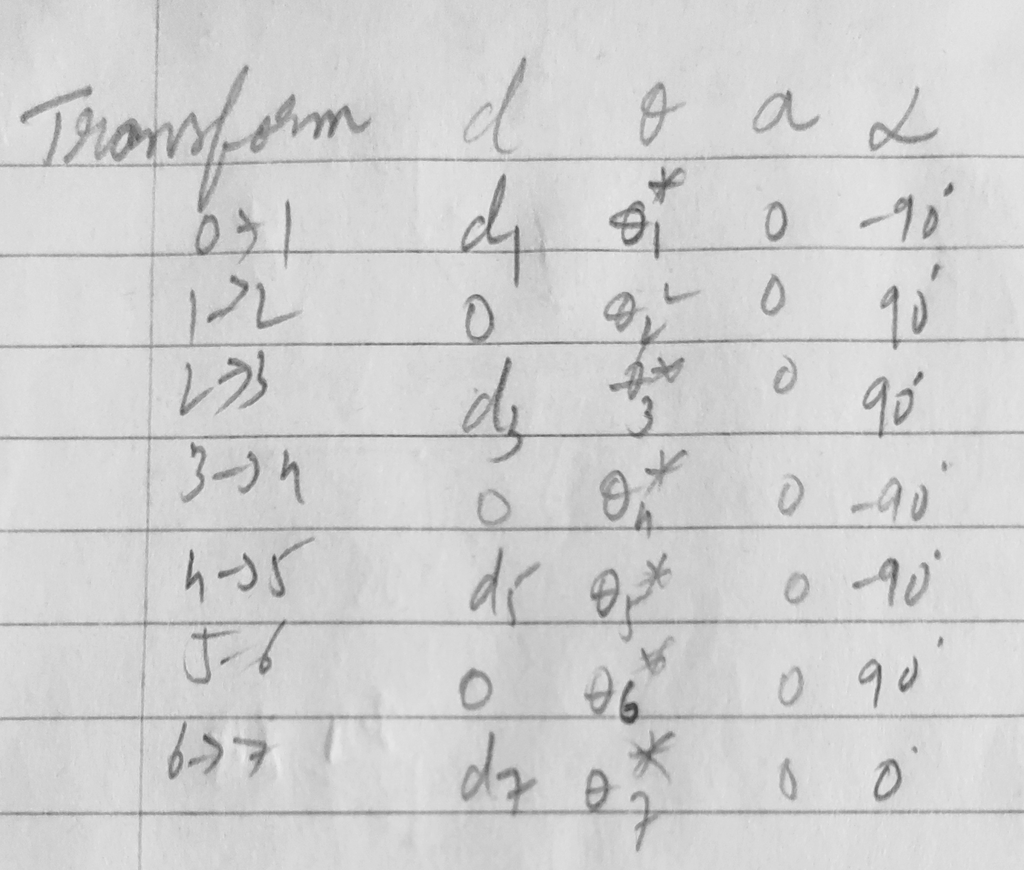

### Now we need to write the individual transformation matrices for each transformation

We know that the general form of a transformation matrix is

```python
xi = symbols('theta_i')
yi = symbols('alpha_i')
di = symbols('d_i')
ai = symbols('a_i')
cxi = sym.cos(xi)
sxi = sym.sin(xi)
cyi = sym.cos(yi)
syi = sym.sin(yi)
T0_i = sym.Matrix([[cxi, -sxi*cyi, sxi*syi, ai*cxi], [sxi, cxi*cyi, -cxi*syi, ai*syi], [0, syi, cyi, di], [0, 0, 0, 1]])
T0_i
```

$\displaystyle \left[\begin{matrix}\cos{\left(\theta_{i} \right)} & - \sin{\left(\theta_{i} \right)} \cos{\left(\alpha_{i} \right)} & \sin{\left(\alpha_{i} \right)} \sin{\left(\theta_{i} \right)} & a_{i} \cos{\left(\theta_{i} \right)}\\\sin{\left(\theta_{i} \right)} & \cos{\left(\alpha_{i} \right)} \cos{\left(\theta_{i} \right)} & - \sin{\left(\alpha_{i} \right)} \cos{\left(\theta_{i} \right)} & a_{i} \sin{\left(\alpha_{i} \right)}\\0 & \sin{\left(\alpha_{i} \right)} & \cos{\left(\alpha_{i} \right)} & d_{i}\\0 & 0 & 0 & 1\end{matrix}\right]$

### Transformation from 0 to 1

```python
x1 = symbols('x1') # Consider x1 as theta 1
d1 = symbols('d1')
c1 = sym.cos(x1)
s1 = sym.sin(x1)
T0_1 = sym.Matrix([[c1, 0, -s1, 0], [s1, 0, c1, 0], [0, -1, 0, d1], [0, 0, 0, 1]])
T0_1
#since the D-H parameter a is zero throughout, I don't mention it anywhere
```

$\displaystyle \left[\begin{matrix}\cos{\left(x_{1} \right)} & 0 & - \sin{\left(x_{1} \right)} & 0\\\sin{\left(x_{1} \right)} & 0 & \cos{\left(x_{1} \right)} & 0\\0 & -1 & 0 & d_{1}\\0 & 0 & 0 & 1\end{matrix}\right]$

### Transformation from 1 to 2

```python
x2 = symbols('x2') # Consider x2 as theta 2
d2 = symbols('d2') # d2 = 0
c2 = sym.cos(x2)
s2 = sym.sin(x2)
T1_2 = sym.Matrix([[c2, 0, s2, 0], [s2, 0, -c2, 0], [0, 1, 0, 0], [0, 0, 0, 1]])
T1_2
```

$\displaystyle \left[\begin{matrix}\cos{\left(x_{2} \right)} & 0 & \sin{\left(x_{2} \right)} & 0\\\sin{\left(x_{2} \right)} & 0 & - \cos{\left(x_{2} \right)} & 0\\0 & 1 & 0 & 0\\0 & 0 & 0 & 1\end{matrix}\right]$

### Transformation from 0 to 2

```python
T0_2 = T0_1*T1_2
T0_2
```

$\displaystyle \left[\begin{matrix}\cos{\left(x_{1} \right)} \cos{\left(x_{2} \right)} & - \sin{\left(x_{1} \right)} & \sin{\left(x_{2} \right)} \cos{\left(x_{1} \right)} & 0\\\sin{\left(x_{1} \right)} \cos{\left(x_{2} \right)} & \cos{\left(x_{1} \right)} & \sin{\left(x_{1} \right)} \sin{\left(x_{2} \right)} & 0\\- \sin{\left(x_{2} \right)} & 0 & \cos{\left(x_{2} \right)} & d_{1}\\0 & 0 & 0 & 1\end{matrix}\right]$

### Transformation from 2 to 3

```python
x3 = symbols('x3') # Consider x3 as theta 3
d3 = symbols('d3')
c3 = sym.cos(x3)
s3 = sym.sin(x3)
T2_3 = sym.Matrix([[c3, 0, s3, 0], [s3, 0, -c3, 0], [0, 1, 0, d3], [0, 0, 0, 1]])
T2_3
```

$\displaystyle \left[\begin{matrix}\cos{\left(x_{3} \right)} & 0 & \sin{\left(x_{3} \right)} & 0\\\sin{\left(x_{3} \right)} & 0 & - \cos{\left(x_{3} \right)} & 0\\0 & 1 & 0 & d_{3}\\0 & 0 & 0 & 1\end{matrix}\right]$

### Transformation from 0 to 3

```python
T0_3 = T0_2*T2_3
T0_3
```

$\displaystyle \left[\begin{matrix}- \sin{\left(x_{1} \right)} \sin{\left(x_{3} \right)} + \cos{\left(x_{1} \right)} \cos{\left(x_{2} \right)} \cos{\left(x_{3} \right)} & \sin{\left(x_{2} \right)} \cos{\left(x_{1} \right)} & \sin{\left(x_{1} \right)} \cos{\left(x_{3} \right)} + \sin{\left(x_{3} \right)} \cos{\left(x_{1} \right)} \cos{\left(x_{2} \right)} & d_{3} \sin{\left(x_{2} \right)} \cos{\left(x_{1} \right)}\\\sin{\left(x_{1} \right)} \cos{\left(x_{2} \right)} \cos{\left(x_{3} \right)} + \sin{\left(x_{3} \right)} \cos{\left(x_{1} \right)} & \sin{\left(x_{1} \right)} \sin{\left(x_{2} \right)} & \sin{\left(x_{1} \right)} \sin{\left(x_{3} \right)} \cos{\left(x_{2} \right)} - \cos{\left(x_{1} \right)} \cos{\left(x_{3} \right)} & d_{3} \sin{\left(x_{1} \right)} \sin{\left(x_{2} \right)}\\- \sin{\left(x_{2} \right)} \cos{\left(x_{3} \right)} & \cos{\left(x_{2} \right)} & - \sin{\left(x_{2} \right)} \sin{\left(x_{3} \right)} & d_{1} + d_{3} \cos{\left(x_{2} \right)}\\0 & 0 & 0 & 1\end{matrix}\right]$

### Transformation from 3 to 4

```python
x4 = symbols('x4') # Consider x4 as theta 4
d4 = symbols('d4') # d4 = 0
c4 = sym.cos(x4)
s4 = sym.sin(x4)
T3_4 = sym.Matrix([[c4, 0, -s4, 0], [s4, 0, c4, 0], [0, -1, 0, 0], [0, 0, 0, 1]])
T3_4
```

$\displaystyle \left[\begin{matrix}\cos{\left(x_{4} \right)} & 0 & - \sin{\left(x_{4} \right)} & 0\\\sin{\left(x_{4} \right)} & 0 & \cos{\left(x_{4} \right)} & 0\\0 & -1 & 0 & 0\\0 & 0 & 0 & 1\end{matrix}\right]$